# Titanic: Machine Learning from Disaster

## Andrew Lau

My first Kaggle competition! I'm excited to get stuck into it. The structure of my analysis as follows:

1. EDA
2. Feature Engineering
   1. New Features
   2. Categorical Features
   3. Missing Data Imputation
3. Fitting Candidate Models
4. Feature selection
5. Hyper-parameter Tuning
6. Model Blending and Final Submission

# Changelog

v14

```python
import numpy as np
import pandas as pd
import sklearn
from matplotlib import pyplot as plt
import random
import seaborn as sns
from sklearn.base import TransformerMixin
from sklearn.impute import SimpleImputer


# Input data files are available in the "../input/" directory.
# For example, running this (by clicking run or pressing Shift+Enter) will list all files under the input directory

# import os
# for dirname, _, filenames in os.walk('/kaggle/input'):
#     for filename in filenames:
#         print(os.path.join(dirname, filename))

# Any results you write to the current directory are saved as output.
%matplotlib inline
np.random.seed(123456)
random.seed(123456)
```

# Import data

```python
from sklearn.model_selection import train_test_split
# fpath_train = "/kaggle/input/titanic/train.csv"
# fpath_test = "/kaggle/input/titanic/test.csv"

def import_split_data():
    fpath_train = "train.csv"
    fpath_test = "test.csv"

    train_valid = pd.read_csv(fpath_train)
    train, valid = train_test_split(train_valid, test_size=0.25, stratify=train_valid.Survived, random_state=123)
    test = pd.read_csv(fpath_test)

    print("train shape:", train.shape)
    print("valid shape:", valid.shape)
    print("test shape:", test.shape)
    train.head()

    return train, valid, test
```

# 1. Initial EDA

Let's do some initial EDA. We begin with some summary statistics and a scatterplot matrix. For plotting, the PassengerId and Name field have been dropped.

Initial exploration of the data's dimensions and a look at some of the columns.

The target is whether they survived or not, this is a classification problem. A frequency histogram of the response shows that it's not too imbalanced.

```python
train.head()
```

|  | PassengerId | Survived | Pclass | Name | Sex | Age | SibSp | Parch | Ticket | Fare | Cabin | Embarked |
| --- | --- | --- | --- | --- | --- | --- | --- | --- | --- | --- | --- | --- |
| 683 | 684 | 0 | 3 | Goodwin, Mr. Charles Edward | male | 14.0 | 5 | 2 | CA 2144 | 46.9000 | NaN | S |
| 421 | 422 | 0 | 3 | Charters, Mr. David | male | 21.0 | 0 | 0 | A/5. 13032 | 7.7333 | NaN | Q |
| 336 | 337 | 0 | 1 | Pears, Mr. Thomas Clinton | male | 29.0 | 1 | 0 | 113776 | 66.6000 | C2 | S |
| 681 | 682 | 1 | 1 | Hassab, Mr. Hammad | male | 27.0 | 0 | 0 | PC 17572 | 76.7292 | D49 | C |
| 610 | 611 | 0 | 3 | Andersson, Mrs. Anders Johan (Alfrida Konstant... | female | 39.0 | 1 | 5 | 347082 | 31.2750 | NaN | S |

```
array([[<matplotlib.axes._subplots.AxesSubplot object at 0x1a1cd7c320>]],
      dtype=object)
```

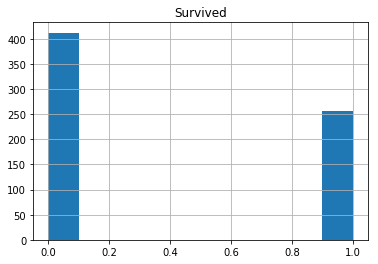

```python
train.loc[:, ['Survived']].hist()
```

```python
train.describe()
```

|  | PassengerId | Survived | Pclass | Age | SibSp | Parch | Fare |
| --- | --- | --- | --- | --- | --- | --- | --- |
| count | 668.000000 | 668.000000 | 668.000000 | 537.000000 | 668.000000 | 668.000000 | 668.000000 |
| mean | 446.872754 | 0.383234 | 2.339820 | 29.050912 | 0.528443 | 0.368263 | 31.336813 |
| std | 260.876341 | 0.486539 | 0.817592 | 14.253775 | 1.135801 | 0.785368 | 51.432948 |
| min | 1.000000 | 0.000000 | 1.000000 | 0.420000 | 0.000000 | 0.000000 | 0.000000 |
| 25% | 221.750000 | 0.000000 | 2.000000 | 20.000000 | 0.000000 | 0.000000 | 7.895800 |
| 50% | 440.000000 | 0.000000 | 3.000000 | 27.000000 | 0.000000 | 0.000000 | 13.500000 |
| 75% | 684.500000 | 1.000000 | 3.000000 | 37.000000 | 1.000000 | 0.000000 | 30.017700 |
| max | 891.000000 | 1.000000 | 3.000000 | 74.000000 | 8.000000 | 5.000000 | 512.329200 |

The pairplot from the `seaborn` module allows us to quickly identify relationships in the data between variables.

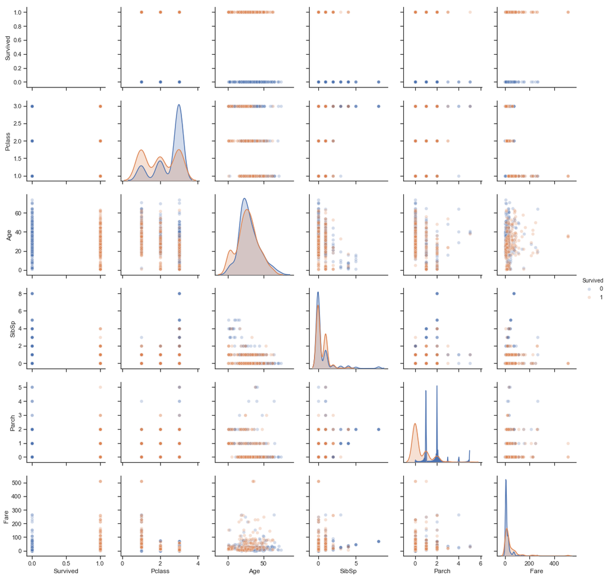

```python
cols = list(train.drop(['PassengerId', 'Name'], axis='columns').columns)
sns.set(style="ticks")
g_1 = sns.pairplot(train.loc[:, cols], hue='Survived', plot_kws={'alpha': 0.25})
```

**Observations:**  
Pclass: 1st class seems to have a better survival rate  
Age: children have a higher survival rate. Working age and the elderly have a lower survival rate  
Fare: higher fare has a higher survival rate, this is correlated with Pclass

Now let's create correlation heat map to easily see what variables are correlated.

Source: https://towardsdatascience.com/better-heatmaps-and-correlation-matrix-plots-in-python-41445d0f2bec

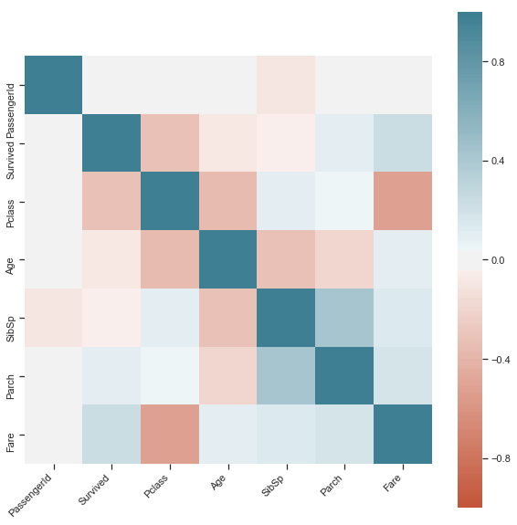

```python
corr = train.corr()
plt.figure(figsize=(10, 10))
ax = sns.heatmap(
    corr,
    vmin=-1, vmax=1, center=0,
    cmap=sns.diverging_palette(20, 220, n=200),
    square=True
)
ax.set_xticklabels(
    ax.get_xticklabels(),
    rotation=45,
    horizontalalignment='right'
);
```

**Observations:**

- Survived is positively correlated with Fare, and negatively correlated with Pclass - those closer to the ship's deck and in more expensive passenger classes had a higher survival rate
- Age is negatively correlated with Pclass, SibSp and Parch - you're generally poorer and do not have a family yet when you are younger

Let's dig into gender and age a bit.

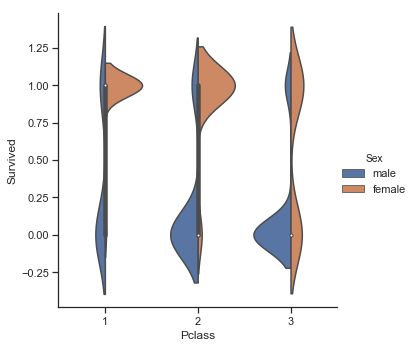

```python
sns.catplot(x="Pclass", y="Survived", kind="violin", hue="Sex", split=True, data=train)
plt.show()
```

It is clear from the above violin chart that those in more expensive classes had a higher survival rate. It is also clear that across all classes, females had a much better survival rate ("women and children on the lifeboats first"). There also appears to be an interaction here; in more expensive classes, females have an even better survival rate than in lower classes.

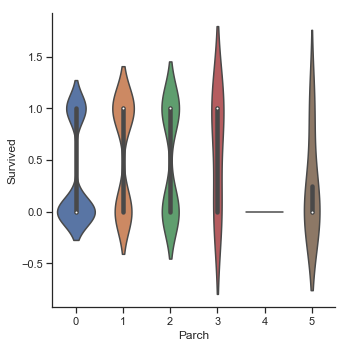

```python
sns.catplot(x="Parch", y="Survived", kind="violin", split=True, data=train)
```

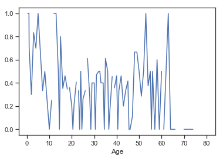

```python
titanic.groupby('Age').Survived.mean().plot()
titanic['under_16'] = (titanic.Age < 16) + 0
```

# Feature Engineering

## Missing data imputation

```python
train, test, valid = import_split_data()
print(train.isnull().sum())
print(valid.isnull().sum())
print(test.isnull().sum())
```

```
train shape: (668, 12)
valid shape: (223, 12)
test shape: (418, 11)
PassengerId      0
Survived         0
Pclass           0
Name             0
Sex              0
Age            131
SibSp            0
Parch            0
Ticket           0
Fare             0
Cabin          532
Embarked         1
dtype: int64
PassengerId      0
Pclass           0
Name             0
Sex              0
Age             86
SibSp            0
Parch            0
Ticket           0
Fare             1
Cabin          327
Embarked         0
dtype: int64
PassengerId      0
Survived         0
Pclass           0
Name             0
Sex              0
Age             46
SibSp            0
Parch            0
Ticket           0
Fare             0
Cabin          155
Embarked         1
dtype: int64
```

```python
class imputer(TransformerMixin):
    def fit(self, X, y=None):
        """ does nothing. we are only transforming"""
        return self

    def transform(self ,X, y=None):
        median = SimpleImputer(strategy='median')
        X.loc[:, ["Age"]] = median.fit_transform(X.loc[:, ["Age"]])
        X.loc[:, ["Fare"]] = median.fit_transform(X.loc[:, ["Fare"]])

        most_frequent = SimpleImputer(strategy='most_frequent')
        X.loc[:, ["Cabin"]] = most_frequent.fit_transform(X.loc[:, ["Cabin"]])
        X.loc[:, ["Embarked"]] = most_frequent.fit_transform(X.loc[:, ["Embarked"]])

        return X
```

## New features and Categorical Features

### Categorical Features have been one hot encoded, dropping the first column (it is redundant)

```python
class feature_engineer(TransformerMixin):
    def __init__(self):
        self._title_list = ['Mrs', 'Mr', 'Master', 'Miss', 'Major', 'Rev', 'Dr', 'Ms', 'Mlle','Col', 'Capt', 'Mme', 'Countess', 'Don', 'Jonkheer']
        self._cabin_list = ['A', 'B', 'C', 'D', 'E', 'F', 'T', 'G', 'Unknown']

    def substrings_in_string(self, big_string, substrings):
        """ helper function for title"""
        for substring in substrings:
            if str.find(big_string, substring) != -1:
                return substring
        print(big_string)
        return np.nan


#     Index(['Age', 'SibSp', 'Parch', 'Fare', 'family_size', 'fare_per_person',
#        'under_16', 'PClass_2', 'PClass_3', 'Sex_male', 'Embarked_Q',
#        'Embarked_S', 'Title_Don', 'Title_Dr', 'Title_Master', 'Title_Miss',
#        'Title_Mr', 'Title_Mrs', 'Title_Ms', 'Title_Rev', 'Deck_B', 'Deck_C',
#        'Deck_D', 'Deck_E', 'Deck_F', 'Deck_G'],
#       dtype='object')

    def replace_titles(self, x):
        title=x['Title']
        if title in ['Don', 'Major', 'Capt', 'Jonkheer', 'Col']:
            return 'Mr'
        elif title in ['Countess', 'Mme']:
            return 'Mrs'
        elif title in ['Mlle', 'Ms']:
            return 'Miss'
        else:
            return title

    def fit(self, X, y=None):
        """ does nothing. we are only transforming"""
        return self

    def transform(self ,X, y=None):
        # family size
        X.loc[:,'family_size'] = X.loc[:, 'SibSp'] + X.loc[:, 'Parch']
        # fare_per_person
        X.loc[:,'fare_per_person'] = X.loc[:, 'Fare'] / (X.loc[:, 'family_size'] + 1)
        # title
        # code from: https://triangleinequality.wordpress.com/2013/09/08/basic-feature-engineering-with-the-titanic-data/
        X.loc[:,'Title'] = X.loc[:, 'Name'].map(lambda x: self.substrings_in_string(x, self._title_list))

        X.loc[:,'Title'] = X.apply(self.replace_titles, axis=1)
#

        # ticket to deck
        X.loc[:,'Deck'] = X.loc[:,'Cabin'].astype(str).map(lambda x: self.substrings_in_string(x, self._cabin_list))
        # age grouping base on one way
#         X.loc[:, 'age_0_16'] = (X.loc[:, 'Age'] < 16) + 0
        X.loc[:, 'age_17_50'] = (X.loc[:, 'Age'] > 16) & (X.loc[:, 'Age'] <= 50) + 0
        X.loc[:, 'age_51_'] = (X.loc[:, 'Age'] >50) + 0
        # one hot encoding
        ohe = pd.get_dummies(X.loc[:,'Pclass'], prefix='PClass', drop_first=True)
        X = pd.concat([X, ohe], sort=False, axis='columns')
        ohe = pd.get_dummies(X.loc[:,'Sex'], prefix='Sex', drop_first=True)
        X = pd.concat([X, ohe], sort=False, axis='columns')
        ohe = pd.get_dummies(X.loc[:,'Embarked'], prefix='Embarked', drop_first=True)
        X = pd.concat([X, ohe], sort=False, axis='columns')
        ohe = pd.get_dummies(X.loc[:,'Title'], prefix='Title', drop_first=True)
        X = pd.concat([X, ohe], sort=False, axis='columns')
        ohe = pd.get_dummies(X.loc[:,'Deck'], prefix='Deck', drop_first=True)
        X = pd.concat([X, ohe], sort=False, axis='columns')

        # drop useless ID vars as well as one hot encoded variables
        X = X.drop(['Name', 'Pclass', 'Sex', 'Embarked', 'Ticket', 'Cabin', 'Title', 'Deck'], axis='columns')
        X = X.drop(['Fare'], axis='columns')

        return X
```

```python
# %%capture
from sklearn.pipeline import Pipeline

train, valid, test = import_split_data()

from sklearn.preprocessing import Imputer

pipe = Pipeline([
                ('imputation', imputer()),
                ('feature_engineer', feature_engineer())])

train = pipe.fit_transform(train)
valid = pipe.fit_transform(valid)
valid = valid.drop('Deck_T', axis='columns') # there is only one deck T in the whole Titanic dataset
test = pipe.fit_transform(test)
```

```
train shape: (668, 12)
valid shape: (223, 12)
test shape: (418, 11)
```

```python
print(train.columns)
print(valid.columns)
print(test.columns)
```

```
Index(['PassengerId', 'Survived', 'Age', 'SibSp', 'Parch', 'family_size',
       'fare_per_person', 'age_17_50', 'age_51_', 'PClass_2', 'PClass_3',
       'Sex_male', 'Embarked_Q', 'Embarked_S', 'Title_Master', 'Title_Miss',
       'Title_Mr', 'Title_Mrs', 'Title_Rev', 'Deck_B', 'Deck_C', 'Deck_D',
       'Deck_E', 'Deck_F', 'Deck_G'],
      dtype='object')
Index(['PassengerId', 'Survived', 'Age', 'SibSp', 'Parch', 'family_size',
       'fare_per_person', 'age_17_50', 'age_51_', 'PClass_2', 'PClass_3',
       'Sex_male', 'Embarked_Q', 'Embarked_S', 'Title_Master', 'Title_Miss',
       'Title_Mr', 'Title_Mrs', 'Title_Rev', 'Deck_B', 'Deck_C', 'Deck_D',
       'Deck_E', 'Deck_F', 'Deck_G'],
      dtype='object')
Index(['PassengerId', 'Age', 'SibSp', 'Parch', 'family_size',
       'fare_per_person', 'age_17_50', 'age_51_', 'PClass_2', 'PClass_3',
       'Sex_male', 'Embarked_Q', 'Embarked_S', 'Title_Master', 'Title_Miss',
       'Title_Mr', 'Title_Mrs', 'Title_Rev', 'Deck_B', 'Deck_C', 'Deck_D',
       'Deck_E', 'Deck_F', 'Deck_G'],
      dtype='object')
```

```python
print(train.shape)
print(valid.shape)
print(test.shape)
```

```
(668, 25)
(223, 25)
(418, 24)
```

```python
print(train.isnull().sum())
print(valid.isnull().sum())
print(test.isnull().sum())
```

```
PassengerId        0
Survived           0
Age                0
SibSp              0
Parch              0
family_size        0
fare_per_person    0
age_17_50          0
age_51_            0
PClass_2           0
PClass_3           0
Sex_male           0
Embarked_Q         0
Embarked_S         0
Title_Master       0
Title_Miss         0
Title_Mr           0
Title_Mrs          0
Title_Rev          0
Deck_B             0
Deck_C             0
Deck_D             0
Deck_E             0
Deck_F             0
Deck_G             0
dtype: int64
PassengerId        0
Survived           0
Age                0
SibSp              0
Parch              0
family_size        0
fare_per_person    0
age_17_50          0
age_51_            0
PClass_2           0
PClass_3           0
Sex_male           0
Embarked_Q         0
Embarked_S         0
```

[output cut: 22 more lines]

```
Sex_male           0
Embarked_Q         0
Embarked_S         0
Title_Master       0
Title_Miss         0
Title_Mr           0
Title_Mrs          0
Title_Rev          0
Deck_B             0
Deck_C             0
Deck_D             0
Deck_E             0
Deck_F             0
Deck_G             0
dtype: int64
```

After all that pre-processing, let's have another look at the correlation heatmap

[figure not shown]

```python
corr = train.corr()
plt.figure(figsize=(10, 10))
ax = sns.heatmap(
    corr,
    vmin=-1, vmax=1, center=0,
    cmap=sns.diverging_palette(20, 220, n=200),
    square=True
)
ax.set_xticklabels(
    ax.get_xticklabels(),
    rotation=45,
    horizontalalignment='right'
);
```

# Baseline model

```python
X_train = train.drop(['PassengerId', 'Survived'], axis='columns')
y_train = train.loc[:, 'Survived']

X_valid = valid.drop(['PassengerId', 'Survived'], axis='columns')
y_valid = valid.loc[:, 'Survived']

X_test = test
```

```python
X_train.head()
```

[output not shown]

```python
features = list(X_train.columns)
```

We begin by testing out a lot of candidate models with default settings to see which gives us a good answer.

```python
%%capture
from sklearn.metrics import accuracy_score
from sklearn.model_selection import cross_val_score, cross_val_predict, GridSearchCV

from sklearn.linear_model import LogisticRegression
from sklearn.neighbors import KNeighborsClassifier
from sklearn.svm import SVC
from sklearn.gaussian_process import GaussianProcessClassifier
from sklearn.tree import DecisionTreeClassifier
from sklearn.ensemble import RandomForestClassifier, AdaBoostClassifier
from sklearn.naive_bayes import GaussianNB
from sklearn.discriminant_analysis import QuadraticDiscriminantAnalysis
from sklearn.neural_network import MLPClassifier
from xgboost import XGBClassifier

models = [RandomForestClassifier(n_estimators=100), KNeighborsClassifier(), SVC(), GaussianProcessClassifier(),
          DecisionTreeClassifier(), AdaBoostClassifier(n_estimators=100), GaussianNB(),
          QuadraticDiscriminantAnalysis(), MLPClassifier(), XGBClassifier(), LogisticRegression()]

model_results = []

for model in models:
    scores = cross_val_score(model, X=X_train, y=y_train, cv=10, n_jobs=7)
    model.fit(X_train, y_train)
    val_score = model.score(X_valid, y_valid)

    model_results.append([str(model.__class__), np.mean(scores), np.std(scores), val_score])
```

```python
pd.DataFrame(model_results, columns=['model', 'CV_score', 'std', 'valid_score']).sort_values('valid_score', ascending=False)
```

|  | model | CV_score | std | valid_score |
| --- | --- | --- | --- | --- |
| 9 | <class 'xgboost.sklearn.XGBClassifier'> | 0.823234 | 0.033263 | 0.829596 |
| 0 | <class 'sklearn.ensemble.forest.RandomForestCl... | 0.815859 | 0.045769 | 0.816143 |
| 8 | <class 'sklearn.neural_network.multilayer_perc... | 0.808151 | 0.048941 | 0.798206 |
| 10 | <class 'sklearn.linear_model.logistic.Logistic... | 0.829182 | 0.038173 | 0.789238 |
| 5 | <class 'sklearn.ensemble.weight_boosting.AdaBo... | 0.806659 | 0.057158 | 0.784753 |
| 2 | <class 'sklearn.svm.classes.SVC'> | 0.763168 | 0.060944 | 0.744395 |
| 4 | <class 'sklearn.tree.tree.DecisionTreeClassifi... | 0.784377 | 0.049850 | 0.726457 |
| 1 | <class 'sklearn.neighbors.classification.KNeig... | 0.737566 | 0.059918 | 0.717489 |
| 3 | <class 'sklearn.gaussian_process.gpc.GaussianP... | 0.724245 | 0.059040 | 0.704036 |
| 7 | <class 'sklearn.discriminant_analysis.Quadrati... | 0.630382 | 0.031030 | 0.645740 |
| 6 | <class 'sklearn.naive_bayes.GaussianNB'> | 0.803651 | 0.043914 | 0.408072 |

Let's do a bit of feature selection.